# Predicting barbel lift efficiency with random forest

Aurel Prosz

2018 január 1

# Summary

The goal in this exercise is to predict from data obtained from wearable devices if a barbel lift was performed right, or the participant did something wrong during the exercise. The efficiency of the barbel lift was ordered into 5 classes, where class *A* was the best. In the future using these prediction algorithms one can measure during a gym session if he or she performed the training in the right way without outside help.

I performed some basic data exploration with the data, and then trained the data set with a simple decision tree and then a more complex random forest algorithm and compared the two.

# The analysis

Loading the dependencies:

```r
require(caret)
require(dplyr)
require(reshape2)
require(ggplot2)
require(ggfortify)
require(e1071)
require(rattle)
```

Let’s load the data set:

```r
train <- read.table("pml-training.csv", sep = ",", header = TRUE)
test <- read.table("pml-testing.csv", sep = ",", header = TRUE)
```

The next step is to filter for the meaningful columns:

```r
train.f1 <- train[, c(8, 9, 10, 38, 39, 40, 41, 42, 43, 44,
                     45, 46, 47, 48, 60, 61, 62, 63, 64, 65, 66, 67 ,68, 84, 85, 86)]
train.f2 <- train[, -c(1:86)]
train.f2 <- train.f2[, c(27,28, 29, 30, 31, 32, 33, 34, 35, 36, 37, 38, 65, 66, 67, 68, 69, 70, 71, 72 ,73, 74)]

train.f <- cbind(train.f1, train.f2)

train.f <- train.f[complete.cases(train.f),]


test.f1 <- test[, c(8, 9, 10, 38, 39, 40, 41, 42, 43, 44,
                      45, 46, 47, 48, 60, 61, 62, 63, 64, 65, 66, 67 ,68, 84, 85, 86)]
test.f2 <- test[, -c(1:86)]
test.f2 <- test.f2[, c(27,28, 29, 30, 31, 32, 33, 34, 35, 36, 37, 38, 65, 66, 67, 68, 69, 70, 71, 72 ,73, 74)]

test.f <- cbind(test.f1, test.f2)

test.f <- test.f[complete.cases(test.f),]
```

The machine learning techniques used in this analysis are very computational heavy, so I partitioned the train data to a smaller data set, which consist only the 10% of the original data set:

```r
part <- createDataPartition(y=train.f$classe,p=0.1,list=FALSE)

training<-train.f[part,]
```

## Plotting the data

In the following part I am going to plot two columns from the train data to get a sense of the structure of the data used for the statistical learning.

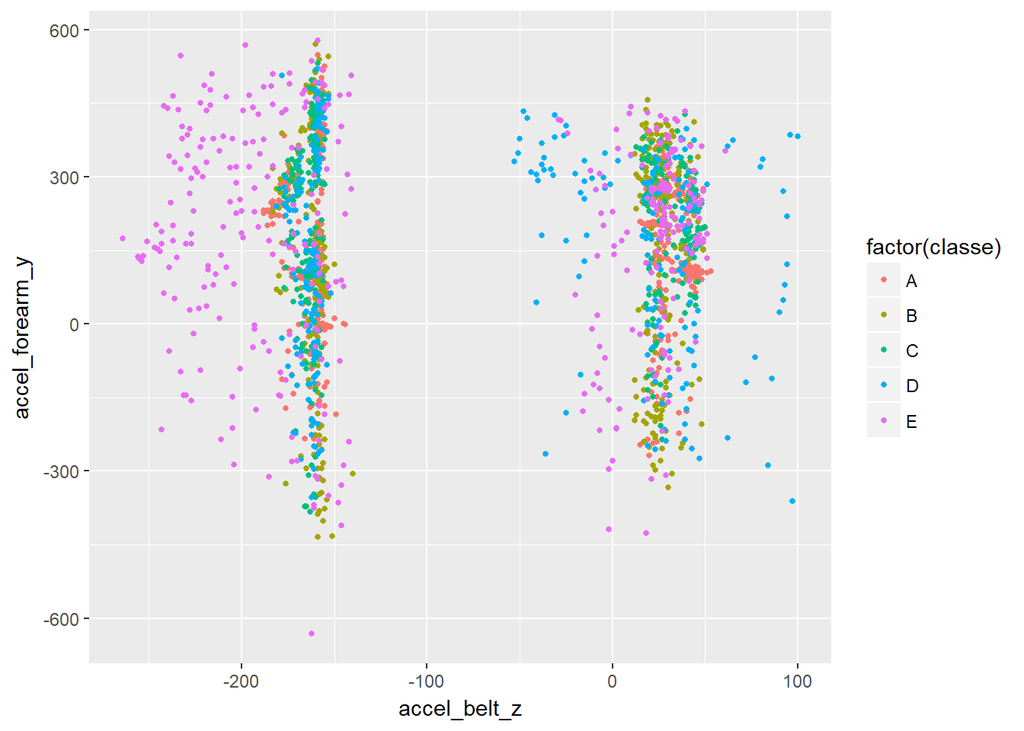

```r
p <- ggplot(training, aes(accel_belt_z, accel_forearm_y)) + geom_point(aes(colour = factor(classe)), size = 1)
p
```

## Decision tree

In this part I am going to perform an analysis using simple decision trees.

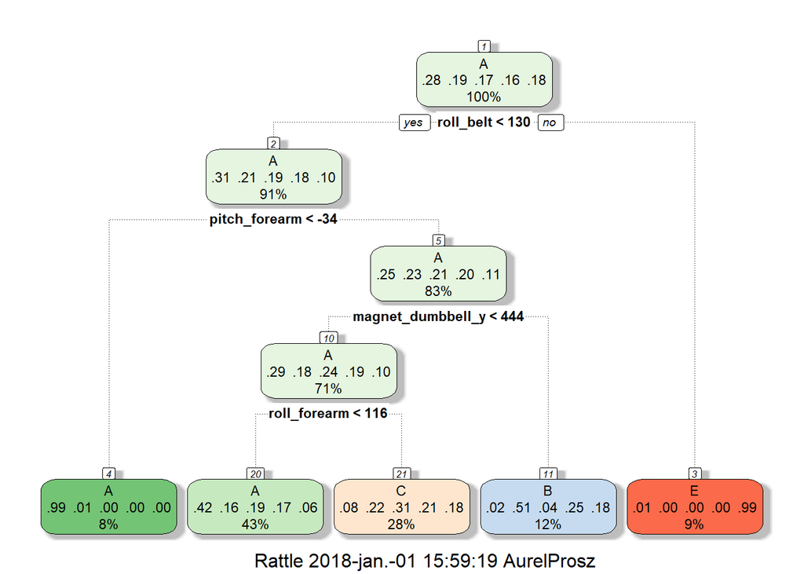

```r
f_model <- train(classe~.,data=training,method="rpart",
                 trControl=trainControl(method="cv",number=5))
fancyRpartPlot(f_model$finalModel)
```

```r
f_model
```

```
## CART
##
## 1964 samples
##   47 predictor
##    5 classes: 'A', 'B', 'C', 'D', 'E'
##
## No pre-processing
## Resampling: Cross-Validated (5 fold)
## Summary of sample sizes: 1571, 1572, 1570, 1571, 1572
## Resampling results across tuning parameters:
##
##   cp          Accuracy   Kappa
##   0.02987198  0.5162786  0.37427992
##   0.05784732  0.3711881  0.13257420
##   0.12304410  0.3156665  0.04789791
##
## Accuracy was used to select the optimal model using the largest value.
## The final value used for the model was cp = 0.02987198.
```

According to the results the accuracy could be much better.

## Random forest

In this part I am going to perform an analysis using a more complex method, the random forest.

```r
rf_model<-train(classe~.,data=training,method="rf",
                trControl=trainControl(method="cv",number=5),
                prox=TRUE,allowParallel=TRUE)

rf_model
```

```
## Random Forest
##
## 1964 samples
##   47 predictor
##    5 classes: 'A', 'B', 'C', 'D', 'E'
##
## No pre-processing
## Resampling: Cross-Validated (5 fold)
## Summary of sample sizes: 1572, 1569, 1570, 1572, 1573
## Resampling results across tuning parameters:
##
##   mtry  Accuracy   Kappa
##    2    0.9358303  0.9187725
##   24    0.9347841  0.9174335
##   47    0.9312204  0.9129402
##
## Accuracy was used to select the optimal model using the largest value.
## The final value used for the model was mtry = 2.
```

```r
summary(rf_model)
```

[output not shown]

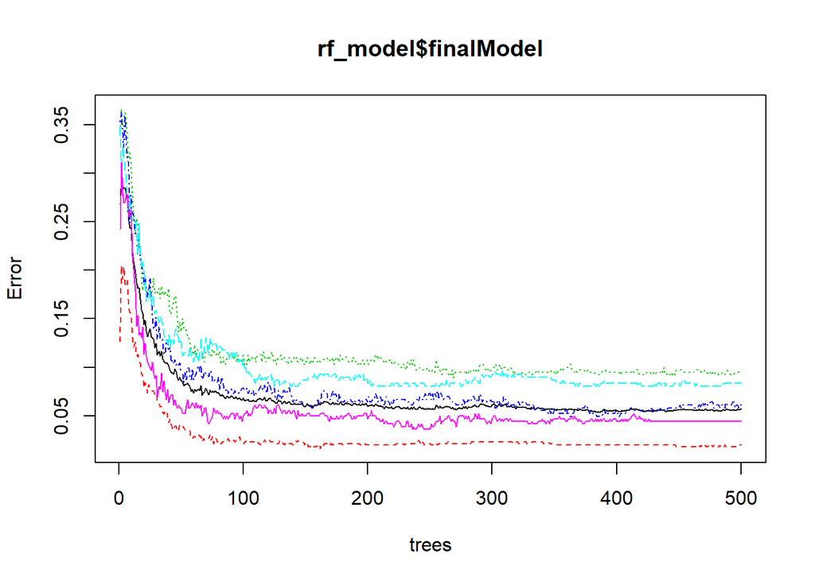

```r
plot(rf_model$finalModel)
```

We can see that the accuracy is much better compared to the simple decision tree algorithm, and has around 90% accuracy.

# Results

I performed two machine learning methods to classify the exercises into five different categories. The random forest method performed the best in this analysis.